# IPBMA_4: Visibility of a nodule inside a noisy image

**Authors**:

- Pablo García Fernández (pablo.garcia.fernandez2@rai.usc.es)
- Javier Goya Pérez (javier.goya@rai.usc.es)
- Sindy Rocío Mojica Gómez (sindyrocio.mojica@rai.usc.es)

```python
# Configuration
import numpy as np
import matplotlib.pyplot as plt
%run ./funciones.py
```

Incident X-ray beam and detector cell specifications

```python
# N0 -> Number of incident photons/mm2
# n -> Number of the detector cells
# cellSize -> Size of the edge of the detector cell in mm
# noduleSize -> Diameter of the nodule in mm
# noduleContrast -> Nodule contrast in %

N0= 4000000
n= 100*100   # Suppose a square shape detector
cellSize= 0.1
```

Creating the noise image, based on the Poisson distribution

```python
imgDataP= createNoiseImageP(N0, n, cellSize)
```

Creating the noise image, based on the Normal distribution

```python
imgDataN= createNoiseImageN(N0, n, cellSize)
```

```python
print(f'{np.max(imgDataP):.1f}, {np.max(imgDataN):.1f}')
print(f'{np.min(imgDataP):.1f}, {np.min(imgDataN):.1f}')
```

```
40724.0, 40780.2
39222.0, 39273.1
```

Show the noise images

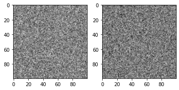

```python
plt.subplot(121)
plt.imshow(imgDataP, cmap="gray")

plt.subplot(122)
plt.imshow(imgDataN, cmap="gray")
plt.show()
```

Plot of a line that crosses the image of the noise images at the center

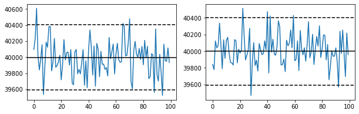

```python
# The interval limits at 2*sigma where included in the plot

plt.figure(figsize=(10, 3))

plt.subplot(121)
plotMiddleLine(imgDataP, N0, cellSize)

plt.subplot(122)
plotMiddleLine(imgDataN, N0, cellSize)
```

Plot of the distribution of the detector cells in terms of the number of photons captured

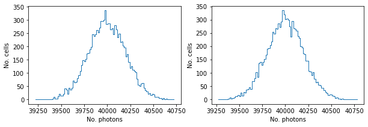

```python
# We use a number of bins= 100, to build the histograms

plt.figure(figsize=(10, 3))

plt.subplot(121)
plotCellDistribution(imgDataP, 100)

plt.subplot(122)
plotCellDistribution(imgDataN, 100)
```

Implementation of a noise image with a nodule superimposed in the center.

```python
# Case 1

noduleSize= 1
noduleContrast= 0.25
imgNodule_1= insertNodule(imgDataP, noduleSize, noduleContrast, N0, cellSize)
```

Showing the noise image and the nodule image for comparison

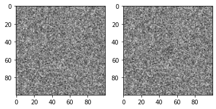

```python
plt.subplot(121)
plt.imshow(imgDataP, cmap="gray")

plt.subplot(122)
plt.imshow(imgNodule_1, cmap="gray")
plt.show()
```

Plot a line across the image through its center

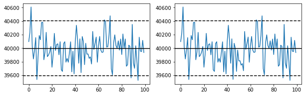

```python
plt.figure(figsize=(10, 3))

plt.subplot(121)
plotMiddleLine(imgDataP, N0, cellSize)

plt.subplot(122)
plotMiddleLine(imgNodule_1, N0, cellSize)
```

```python
# Case 2

noduleSize= 1
noduleContrast= 1
imgNodule_2= insertNodule(imgDataP, noduleSize, noduleContrast, N0, cellSize)
```

Showing the noise image and the nodule image for comparison

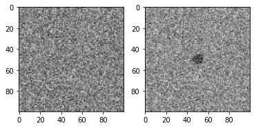

```python
plt.subplot(121)
plt.imshow(imgDataP, cmap="gray")

plt.subplot(122)
plt.imshow(imgNodule_2, cmap="gray")
plt.show()
```

Plot a line across the image through its center

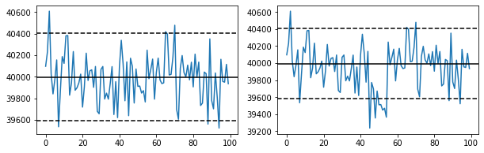

```python
plt.figure(figsize=(10, 3))

plt.subplot(121)
plotMiddleLine(imgDataP, N0, cellSize)

plt.subplot(122)
plotMiddleLine(imgNodule_2, N0, cellSize)
```

```python
# Case 3

noduleSize= 0.1
noduleContrast= 1
imgNodule_3= insertNodule(imgDataP, noduleSize, noduleContrast, N0, cellSize)
```

Showing the noise image and the nodule image for comparison

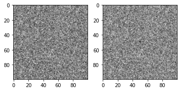

```python
plt.subplot(121)
plt.imshow(imgDataP, cmap="gray")

plt.subplot(122)
plt.imshow(imgNodule_3, cmap="gray")
plt.show()
```

Plot of a line across the image through its center

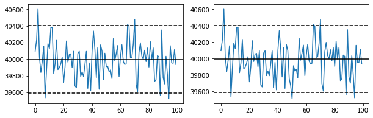

```python
plt.figure(figsize=(10, 3))

plt.subplot(121)
plotMiddleLine(imgDataP, N0, cellSize)

plt.subplot(122)
plotMiddleLine(imgNodule_3, N0, cellSize)
```